# Machine Learning Class Assignment

Edmund A. Marcarelli

January 14, 2016

### Preliminary data analysis and data tidying

The data set provided for the project involves Human Acttivity Recognition described here: http://groupware.les.inf.puc-rio.br/har. It has **19622** observations and **160** variables.

The first step of this analysis is to split the data into training and test sets. Next examine the data set and do some intial tidying it up. I looked for near-zero variables and variables with significant missing values (more than 10,000 observations). All of these variables were dropped. This left a data set with **14718** observations and **54** variables. I also dropped variables that won’t be used in the analysis: user name and timestamps.

Given the relatively large number of potential predictors some further analysis of the data is required before selecting features for the model.

### Data analysis and model selection

The variable *classe* indicates how an exercise was done. “A” indicating a correct execution and all other values (B through E) indicating execution with various mistakes. I created a new outcome variable, *A_curl*, which is 1 for correct execution and 0 for incorrect. I used this variable to do some of my analysis. I separated the 1 and zeros and calculated means for each variavble by group. I then took the absolute value of the differences. I set up a process that let me choose from these variables above a certain threshold in the differences. Using a glm model I selected all variables with a difference in means that put them at 75% or above in the list of variables, then 50%, then 25%. As expected these gave progressively better results for accuracy, sensitivity and specificity as the number of variables increased.

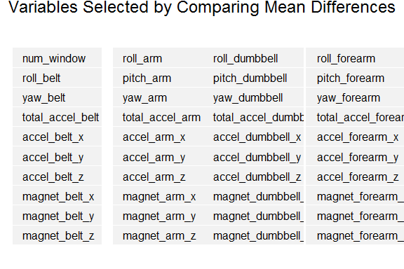

Using a *gbm* model with these variables, I was able to substantially increase accuracy using the same set of variables. The results are described below.

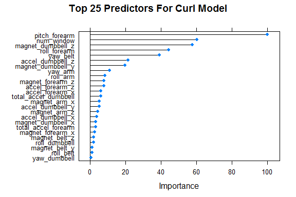

The *gbm* model reaches **99.4%** accuracy. The plot above shows the relative importance of the top 25 (of 40) variables in the model. It demonstrates that importance trails off significantly. Given this diminishing importance, and to minimize the risk of overfitting, I decided to use just the top 10 variables in a new gbm model.

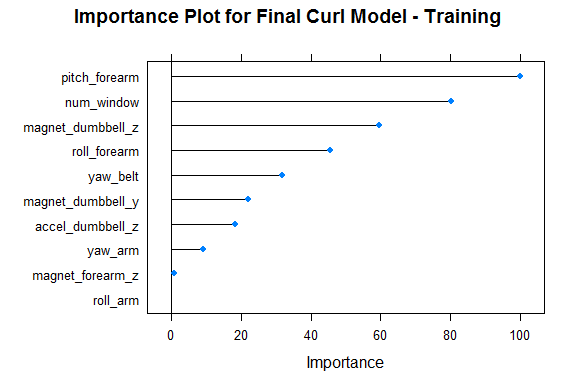

The model was run using K-fold cross-validation (k = 3). This model gives this level of accuracy: **99.5** .

### Results

- Note: This model run was only done once so the code in the .Rmd file is set to eval=FALSE.*